# CSC498H Project Phase I

### Ordinal Encoding Scheme

```r
ord_dataset <- data
ord_dataset$V1 <- as.numeric(factor(data$Buying_Price))
ord_dataset$V2 <- as.numeric(factor(data$Maintenance_Price))
ord_dataset$V3 <- as.numeric(factor(data$Number_of_Doors))
ord_dataset$V4 <- as.numeric(factor(data$Capacity))
ord_dataset$V5 <- as.numeric(factor(data$Luggage_Boot_Size))
ord_dataset$V6 <- as.numeric(factor(data$Estimated_Safety))
ord_dataset$V7 <- data$Acceptability
```

```r
ord_data_X <- ord_dataset[c("V1", "V2", "V5", "V6")] # pick features here
ord_data_y <- ord_dataset["V7"]
ord_train_data_X <- ord_data_X[train_indices, ]
ord_train_data_y <- ord_data_y$V7[train_indices]
ord_test_data_X <- ord_data_X[-train_indices, ]
ord_test_data_y <- ord_data_y$V7[-train_indices]
```

Let’s fit another LDA model on this dataset

```r
lda_ord_model <- lda(ord_train_data_y ~ ., data=ord_train_data_X)
print(lda_ord_model)
```

```
## Call:
## lda(ord_train_data_y ~ ., data = ord_train_data_X)
##
## Prior probabilities of groups:
##       bad      good
## 0.5025641 0.4974359
##
## Group means:
##            V1       V2       V5       V6
## bad  2.520408 2.612245 1.989796 2.020408
## good 1.391753 2.288660 1.628866 1.597938
##
## Coefficients of linear discriminants:
##           LD1
## V1 -1.0981945
## V2 -0.1994330
## V5 -0.5884641
## V6 -0.4884710
```

Similarly, let’s find the predictions, classes, and create a new confusion matrix

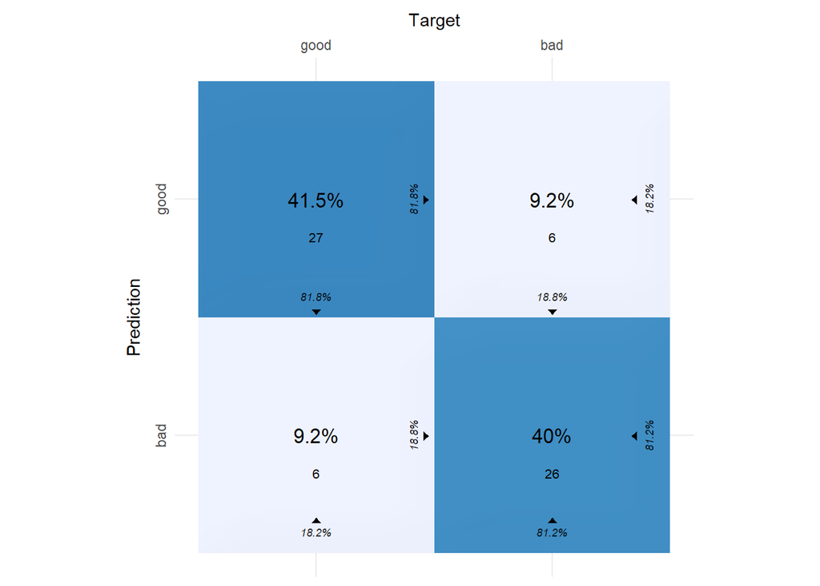

```r
lda_ord_predictions <- predict(lda_ord_model, ord_test_data_X)
lda_ord_classes <- lda_ord_predictions$class
lda_ord_confusion_matrix <- cvms::confusion_matrix(targets = lda_ord_classes, predictions = actual)
plot_confusion_matrix(lda_ord_confusion_matrix$`Confusion Matrix`[[1]])
```

Let’s examine in detail some metrics for this fit:

```r
lda_ord_confusion_matrix$`Balanced Accuracy`
```

```
## [1] 0.8153409
```

We can see our model displays an accuracy of `81.53%` which is decent, but a step-down from one-hot encoding. Moving on to the rest of the metrics:

```r
print(lda_ord_confusion_matrix$Sensitivity)
```

```
## [1] 0.8181818
```

```r
print(lda_ord_confusion_matrix$Specificity)
```

```
## [1] 0.8125
```

```r
print(lda_ord_confusion_matrix$F1)
```

```
## [1] 0.8181818
```

We see the different encodings had a significant impact on LDA’s performance as we notice a drop in all metrics by approximately 14% on average.

## Quadratic Discriminant Analysis

### One-Hot Encoding

For QDA, using one-hot encoding resulted in rank deficiencies in the dataset and prevented the model for fitting

### Ordinal Encoding

For this part, we can reuse the same data from Ordinal Encoding for LDA and fit on a `qda` model:

```r
qda_model <- qda(ord_train_data_y ~ ., data=ord_train_data_X)
```

To observe which predictors seem significant in QDA, we can examine the differnece of the means for each class and group. A relatively large difference in the means for each class points to significant features (those that facilitate clean separation of observations) and the opposite is true.

```r
mean_diffs <- abs(diff(qda_model$means))
mean_diffs
```

```
##            V1        V2        V5      V6
## good 1.128656 0.3235851 0.3609299 0.42247
```

We can see here, that `V1` (Buying Price) seems to be doing a better job than the other features at separating `good` and `bad` cars!

Let’s now use this model to predict on our test data and check out some metrics!

```r
qda_predictions <- predict(qda_model, ord_test_data_X)
qda_pred_classes <- qda_predictions$class
```

We need to modify `actual` classes slightly here because of some type inconsistencies due to the outputs of QDA model

```r
actual <- as.factor(actual)
```

Now we can create the confusion matrix as usual

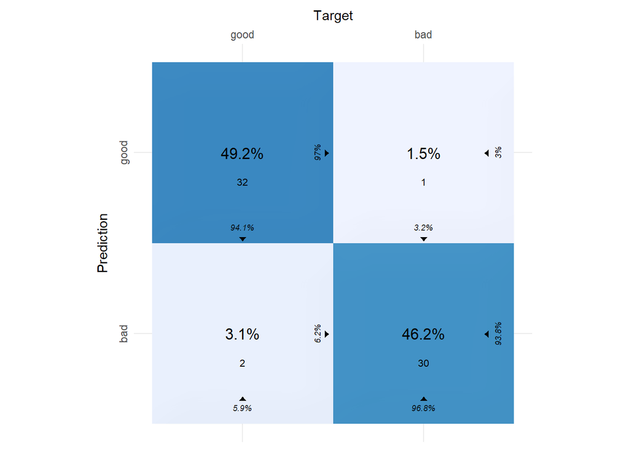

```r
qda_confusion_matrix <- cvms::confusion_matrix(targets = qda_pred_classes, predictions = actual)
plot_confusion_matrix(qda_confusion_matrix$`Confusion Matrix`[[1]])
```

Here are the metrics for this model:

```r
print(qda_confusion_matrix$`Balanced Accuracy`)
```

```
## [1] 0.9544592
```

```r
print(qda_confusion_matrix$Sensitivity)
```

```
## [1] 0.9411765
```

```r
print(qda_confusion_matrix$Specificity)
```

```
## [1] 0.9677419
```

```r
print(qda_confusion_matrix$F1)
```

```
## [1] 0.9552239
```

QDA seems to perform significantly better than LDA given ordinal encoding of the features